# Risk Factor Analysis

## Outcome Variable

**Outcome Variable:** pers_wast

## Predictor Variables

**Intervention Variable:** birthwt

**Adjustment Set:**

- arm
- sex
- W_mage
- meducyrs
- feducyrs
- vagbrth
- single
- brthmon
- W_parity
- delta_W_mage
- delta_meducyrs
- delta_feducyrs
- delta_vagbrth
- delta_single
- delta_brthmon
- delta_W_parity

## Stratifying Variables

The analysis was stratified on these variable(s):

- agecat
- studyid
- country

## Data Summary

| agecat | studyid | country | birthwt | pers_wast | n_cell | n |
| --- | --- | --- | --- | --- | --- | --- |
| 0-24 months | ki0047075b-MAL-ED | BANGLADESH | Normal or high birthweight | 0 | 185 | 242 |
| 0-24 months | ki0047075b-MAL-ED | BANGLADESH | Normal or high birthweight | 1 | 8 | 242 |
| 0-24 months | ki0047075b-MAL-ED | BANGLADESH | Low birth weight | 0 | 45 | 242 |
| 0-24 months | ki0047075b-MAL-ED | BANGLADESH | Low birth weight | 1 | 4 | 242 |
| 0-24 months | ki0047075b-MAL-ED | BRAZIL | Normal or high birthweight | 0 | 205 | 217 |
| 0-24 months | ki0047075b-MAL-ED | BRAZIL | Normal or high birthweight | 1 | 2 | 217 |
| 0-24 months | ki0047075b-MAL-ED | BRAZIL | Low birth weight | 0 | 10 | 217 |
| 0-24 months | ki0047075b-MAL-ED | BRAZIL | Low birth weight | 1 | 0 | 217 |
| 0-24 months | ki0047075b-MAL-ED | INDIA | Normal or high birthweight | 0 | 181 | 233 |
| 0-24 months | ki0047075b-MAL-ED | INDIA | Normal or high birthweight | 1 | 14 | 233 |
| 0-24 months | ki0047075b-MAL-ED | INDIA | Low birth weight | 0 | 33 | 233 |
| 0-24 months | ki0047075b-MAL-ED | INDIA | Low birth weight | 1 | 5 | 233 |
| 0-24 months | ki0047075b-MAL-ED | NEPAL | Normal or high birthweight | 0 | 207 | 231 |
| 0-24 months | ki0047075b-MAL-ED | NEPAL | Normal or high birthweight | 1 | 3 | 231 |
| 0-24 months | ki0047075b-MAL-ED | NEPAL | Low birth weight | 0 | 21 | 231 |
| 0-24 months | ki0047075b-MAL-ED | NEPAL | Low birth weight | 1 | 0 | 231 |
| 0-24 months | ki0047075b-MAL-ED | PERU | Normal or high birthweight | 0 | 262 | 281 |
| 0-24 months | ki0047075b-MAL-ED | PERU | Normal or high birthweight | 1 | 1 | 281 |
| 0-24 months | ki0047075b-MAL-ED | PERU | Low birth weight | 0 | 18 | 281 |
| 0-24 months | ki0047075b-MAL-ED | PERU | Low birth weight | 1 | 0 | 281 |
| 0-24 months | ki0047075b-MAL-ED | SOUTH AFRICA | Normal or high birthweight | 0 | 254 | 273 |
| 0-24 months | ki0047075b-MAL-ED | SOUTH AFRICA | Normal or high birthweight | 1 | 2 | 273 |
| 0-24 months | ki0047075b-MAL-ED | SOUTH AFRICA | Low birth weight | 0 | 17 | 273 |
| 0-24 months | ki0047075b-MAL-ED | SOUTH AFRICA | Low birth weight | 1 | 0 | 273 |
| 0-24 months | ki0047075b-MAL-ED | TANZANIA, UNITED REPUBLIC OF | Normal or high birthweight | 0 | 123 | 129 |
| 0-24 months | ki0047075b-MAL-ED | TANZANIA, UNITED REPUBLIC OF | Normal or high birthweight | 1 | 0 | 129 |
| 0-24 months | ki0047075b-MAL-ED | TANZANIA, UNITED REPUBLIC OF | Low birth weight | 0 | 6 | 129 |
| 0-24 months | ki0047075b-MAL-ED | TANZANIA, UNITED REPUBLIC OF | Low birth weight | 1 | 0 | 129 |
| 0-24 months | ki1000108-CMC-V-BCS-2002 | INDIA | Normal or high birthweight | 0 | 312 | 373 |
| 0-24 months | ki1000108-CMC-V-BCS-2002 | INDIA | Normal or high birthweight | 1 | 18 | 373 |

[output cut: 298 more lines]

The following strata were considered:

- agecat: 0-24 months, studyid: ki0047075b-MAL-ED, country: BANGLADESH
- agecat: 0-24 months, studyid: ki0047075b-MAL-ED, country: BRAZIL
- agecat: 0-24 months, studyid: ki0047075b-MAL-ED, country: INDIA
- agecat: 0-24 months, studyid: ki0047075b-MAL-ED, country: NEPAL
- agecat: 0-24 months, studyid: ki0047075b-MAL-ED, country: PERU
- agecat: 0-24 months, studyid: ki0047075b-MAL-ED, country: SOUTH AFRICA
- agecat: 0-24 months, studyid: ki0047075b-MAL-ED, country: TANZANIA, UNITED REPUBLIC OF
- agecat: 0-24 months, studyid: ki1000108-CMC-V-BCS-2002, country: INDIA
- agecat: 0-24 months, studyid: ki1000108-IRC, country: INDIA
- agecat: 0-24 months, studyid: ki1000109-EE, country: PAKISTAN
- agecat: 0-24 months, studyid: ki1000109-ResPak, country: PAKISTAN
- agecat: 0-24 months, studyid: ki1000304b-SAS-CompFeed, country: INDIA
- agecat: 0-24 months, studyid: ki1017093-NIH-Birth, country: BANGLADESH
- agecat: 0-24 months, studyid: ki1017093b-PROVIDE, country: BANGLADESH
- agecat: 0-24 months, studyid: ki1017093c-NIH-Crypto, country: BANGLADESH
- agecat: 0-24 months, studyid: ki1066203-TanzaniaChild2, country: TANZANIA, UNITED REPUBLIC OF
- agecat: 0-24 months, studyid: ki1101329-Keneba, country: GAMBIA
- agecat: 0-24 months, studyid: ki1114097-CMIN, country: BANGLADESH
- agecat: 0-24 months, studyid: ki1114097-CMIN, country: BRAZIL
- agecat: 0-24 months, studyid: ki1114097-CMIN, country: GUINEA-BISSAU
- agecat: 0-24 months, studyid: ki1114097-CMIN, country: PERU
- agecat: 0-24 months, studyid: ki1114097-CONTENT, country: PERU
- agecat: 0-24 months, studyid: ki1119695-PROBIT, country: BELARUS
- agecat: 0-24 months, studyid: ki1126311-ZVITAMBO, country: ZIMBABWE
- agecat: 0-24 months, studyid: ki1135781-COHORTS, country: GUATEMALA
- agecat: 0-24 months, studyid: ki1135781-COHORTS, country: INDIA
- agecat: 0-24 months, studyid: ki1135781-COHORTS, country: PHILIPPINES
- agecat: 0-24 months, studyid: kiGH5241-JiVitA-3, country: BANGLADESH
- agecat: 0-24 months, studyid: kiGH5241-JiVitA-4, country: BANGLADESH
- agecat: 0-6 months, studyid: ki0047075b-MAL-ED, country: BANGLADESH
- agecat: 0-6 months, studyid: ki0047075b-MAL-ED, country: BRAZIL
- agecat: 0-6 months, studyid: ki0047075b-MAL-ED, country: INDIA
- agecat: 0-6 months, studyid: ki0047075b-MAL-ED, country: NEPAL
- agecat: 0-6 months, studyid: ki0047075b-MAL-ED, country: PERU
- agecat: 0-6 months, studyid: ki0047075b-MAL-ED, country: SOUTH AFRICA
- agecat: 0-6 months, studyid: ki0047075b-MAL-ED, country: TANZANIA, UNITED REPUBLIC OF
- agecat: 0-6 months, studyid: ki1000108-CMC-V-BCS-2002, country: INDIA
- agecat: 0-6 months, studyid: ki1000108-IRC, country: INDIA
- agecat: 0-6 months, studyid: ki1000109-EE, country: PAKISTAN
- agecat: 0-6 months, studyid: ki1000109-ResPak, country: PAKISTAN
- agecat: 0-6 months, studyid: ki1017093-NIH-Birth, country: BANGLADESH
- agecat: 0-6 months, studyid: ki1017093b-PROVIDE, country: BANGLADESH
- agecat: 0-6 months, studyid: ki1017093c-NIH-Crypto, country: BANGLADESH
- agecat: 0-6 months, studyid: ki1066203-TanzaniaChild2, country: TANZANIA, UNITED REPUBLIC OF
- agecat: 0-6 months, studyid: ki1101329-Keneba, country: GAMBIA
- agecat: 0-6 months, studyid: ki1114097-CMIN, country: BANGLADESH
- agecat: 0-6 months, studyid: ki1114097-CMIN, country: GUINEA-BISSAU
- agecat: 0-6 months, studyid: ki1114097-CMIN, country: PERU
- agecat: 0-6 months, studyid: ki1114097-CONTENT, country: PERU
- agecat: 0-6 months, studyid: ki1119695-PROBIT, country: BELARUS
- agecat: 0-6 months, studyid: ki1126311-ZVITAMBO, country: ZIMBABWE
- agecat: 0-6 months, studyid: ki1135781-COHORTS, country: PHILIPPINES
- agecat: 0-6 months, studyid: kiGH5241-JiVitA-3, country: BANGLADESH
- agecat: 6-24 months, studyid: ki0047075b-MAL-ED, country: BANGLADESH
- agecat: 6-24 months, studyid: ki0047075b-MAL-ED, country: BRAZIL
- agecat: 6-24 months, studyid: ki0047075b-MAL-ED, country: INDIA
- agecat: 6-24 months, studyid: ki0047075b-MAL-ED, country: NEPAL
- agecat: 6-24 months, studyid: ki0047075b-MAL-ED, country: PERU
- agecat: 6-24 months, studyid: ki0047075b-MAL-ED, country: SOUTH AFRICA
- agecat: 6-24 months, studyid: ki0047075b-MAL-ED, country: TANZANIA, UNITED REPUBLIC OF
- agecat: 6-24 months, studyid: ki1000108-CMC-V-BCS-2002, country: INDIA
- agecat: 6-24 months, studyid: ki1000108-IRC, country: INDIA
- agecat: 6-24 months, studyid: ki1000109-EE, country: PAKISTAN
- agecat: 6-24 months, studyid: ki1000109-ResPak, country: PAKISTAN
- agecat: 6-24 months, studyid: ki1000304b-SAS-CompFeed, country: INDIA
- agecat: 6-24 months, studyid: ki1017093-NIH-Birth, country: BANGLADESH
- agecat: 6-24 months, studyid: ki1017093b-PROVIDE, country: BANGLADESH
- agecat: 6-24 months, studyid: ki1017093c-NIH-Crypto, country: BANGLADESH
- agecat: 6-24 months, studyid: ki1066203-TanzaniaChild2, country: TANZANIA, UNITED REPUBLIC OF
- agecat: 6-24 months, studyid: ki1101329-Keneba, country: GAMBIA
- agecat: 6-24 months, studyid: ki1114097-CMIN, country: BANGLADESH
- agecat: 6-24 months, studyid: ki1114097-CMIN, country: BRAZIL
- agecat: 6-24 months, studyid: ki1114097-CMIN, country: GUINEA-BISSAU
- agecat: 6-24 months, studyid: ki1114097-CMIN, country: PERU
- agecat: 6-24 months, studyid: ki1114097-CONTENT, country: PERU
- agecat: 6-24 months, studyid: ki1119695-PROBIT, country: BELARUS
- agecat: 6-24 months, studyid: ki1126311-ZVITAMBO, country: ZIMBABWE
- agecat: 6-24 months, studyid: ki1135781-COHORTS, country: GUATEMALA
- agecat: 6-24 months, studyid: ki1135781-COHORTS, country: INDIA
- agecat: 6-24 months, studyid: ki1135781-COHORTS, country: PHILIPPINES
- agecat: 6-24 months, studyid: kiGH5241-JiVitA-3, country: BANGLADESH
- agecat: 6-24 months, studyid: kiGH5241-JiVitA-4, country: BANGLADESH

### Dropped Strata

Some strata were dropped due to rare outcomes:

- agecat: 0-24 months, studyid: ki0047075b-MAL-ED, country: BANGLADESH
- agecat: 0-24 months, studyid: ki0047075b-MAL-ED, country: BRAZIL
- agecat: 0-24 months, studyid: ki0047075b-MAL-ED, country: NEPAL
- agecat: 0-24 months, studyid: ki0047075b-MAL-ED, country: PERU
- agecat: 0-24 months, studyid: ki0047075b-MAL-ED, country: SOUTH AFRICA
- agecat: 0-24 months, studyid: ki0047075b-MAL-ED, country: TANZANIA, UNITED REPUBLIC OF
- agecat: 0-24 months, studyid: ki1000109-ResPak, country: PAKISTAN
- agecat: 0-24 months, studyid: ki1114097-CMIN, country: BANGLADESH
- agecat: 0-24 months, studyid: ki1114097-CMIN, country: BRAZIL
- agecat: 0-24 months, studyid: ki1114097-CMIN, country: GUINEA-BISSAU
- agecat: 0-24 months, studyid: ki1114097-CMIN, country: PERU
- agecat: 0-24 months, studyid: ki1114097-CONTENT, country: PERU
- agecat: 0-24 months, studyid: ki1119695-PROBIT, country: BELARUS
- agecat: 0-24 months, studyid: ki1135781-COHORTS, country: GUATEMALA
- agecat: 0-6 months, studyid: ki0047075b-MAL-ED, country: BANGLADESH
- agecat: 0-6 months, studyid: ki0047075b-MAL-ED, country: BRAZIL
- agecat: 0-6 months, studyid: ki0047075b-MAL-ED, country: NEPAL
- agecat: 0-6 months, studyid: ki0047075b-MAL-ED, country: PERU
- agecat: 0-6 months, studyid: ki0047075b-MAL-ED, country: SOUTH AFRICA
- agecat: 0-6 months, studyid: ki0047075b-MAL-ED, country: TANZANIA, UNITED REPUBLIC OF
- agecat: 0-6 months, studyid: ki1000109-ResPak, country: PAKISTAN
- agecat: 0-6 months, studyid: ki1017093-NIH-Birth, country: BANGLADESH
- agecat: 0-6 months, studyid: ki1017093c-NIH-Crypto, country: BANGLADESH
- agecat: 0-6 months, studyid: ki1114097-CMIN, country: BANGLADESH
- agecat: 0-6 months, studyid: ki1114097-CMIN, country: GUINEA-BISSAU
- agecat: 0-6 months, studyid: ki1114097-CMIN, country: PERU
- agecat: 0-6 months, studyid: ki1114097-CONTENT, country: PERU
- agecat: 0-6 months, studyid: ki1119695-PROBIT, country: BELARUS
- agecat: 0-6 months, studyid: ki1126311-ZVITAMBO, country: ZIMBABWE
- agecat: 0-6 months, studyid: kiGH5241-JiVitA-3, country: BANGLADESH
- agecat: 6-24 months, studyid: ki0047075b-MAL-ED, country: BANGLADESH
- agecat: 6-24 months, studyid: ki0047075b-MAL-ED, country: BRAZIL
- agecat: 6-24 months, studyid: ki0047075b-MAL-ED, country: NEPAL
- agecat: 6-24 months, studyid: ki0047075b-MAL-ED, country: PERU
- agecat: 6-24 months, studyid: ki0047075b-MAL-ED, country: SOUTH AFRICA
- agecat: 6-24 months, studyid: ki0047075b-MAL-ED, country: TANZANIA, UNITED REPUBLIC OF
- agecat: 6-24 months, studyid: ki1000109-ResPak, country: PAKISTAN
- agecat: 6-24 months, studyid: ki1114097-CMIN, country: BANGLADESH
- agecat: 6-24 months, studyid: ki1114097-CMIN, country: BRAZIL
- agecat: 6-24 months, studyid: ki1114097-CMIN, country: GUINEA-BISSAU
- agecat: 6-24 months, studyid: ki1114097-CMIN, country: PERU
- agecat: 6-24 months, studyid: ki1114097-CONTENT, country: PERU
- agecat: 6-24 months, studyid: ki1119695-PROBIT, country: BELARUS
- agecat: 6-24 months, studyid: ki1135781-COHORTS, country: GUATEMALA

## Methods Detail

We’re interested in the causal parameters $E[Y_a]$ for all values of $a \in \mathcal{A}$. These parameters represent the mean outcome if, possibly contrary to fact, we intervened to set all units to have $A=a$. Under the randomization and positivity assumptions, these are identified by the statistical parameters $\psi_a=E_W[E_{Y|A,W}(Y|A=a,W)]$. In addition, we’re interested in the mean of $Y$, $E[Y]$ under no intervention (the observed mean). We will estimate these parameters by using SuperLearner to fit the relevant likelihood factors – $E_{Y|A,W}(Y|A=a,W)$ and $p(A=a|W)$, and then updating our likelihood fit using a joint TMLE.

For unadjusted analyses ($W=\{\}$), initial likelihoods were estimated using Lrnr_glm to estimate the simple $E(Y|A)$ and Lrnr_mean to estimate $p(A)$. For adjusted analyses, a small library containing Lrnr_glmnet, Lrnr_xgboost, and Lrnr_mean was used.

Having estimated these parameters, we will then use the delta method to estimate relative risks and attributable risks relative to a prespecified baseline level of $A$.

# Results Detail

## Results Plots

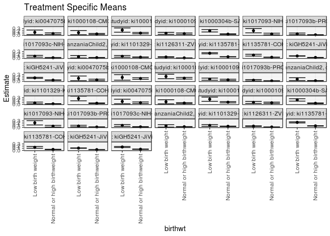

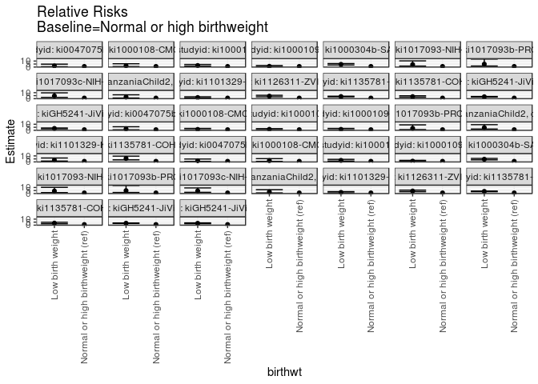

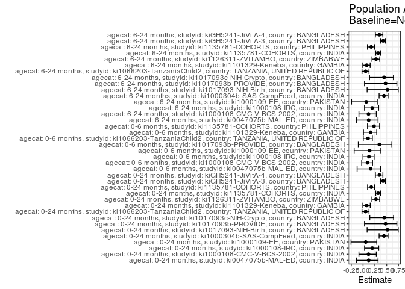

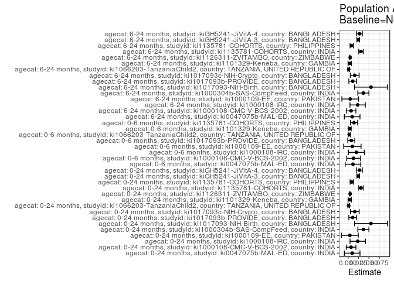

## Results Table

### Parameter: TSM

| agecat | studyid | country | intervention_level | baseline_level | estimate | ci_lower | ci_upper |
| --- | --- | --- | --- | --- | --- | --- | --- |
| 0-24 months | ki0047075b-MAL-ED | INDIA | Normal or high birthweight | NA | 0.0717949 | 0.0354843 | 0.1081055 |
| 0-24 months | ki0047075b-MAL-ED | INDIA | Low birth weight | NA | 0.1315789 | 0.0238708 | 0.2392871 |
| 0-24 months | ki1000108-CMC-V-BCS-2002 | INDIA | Normal or high birthweight | NA | 0.0545455 | 0.0300112 | 0.0790798 |
| 0-24 months | ki1000108-CMC-V-BCS-2002 | INDIA | Low birth weight | NA | 0.1162791 | 0.0203379 | 0.2122203 |
| 0-24 months | ki1000108-IRC | INDIA | Normal or high birthweight | NA | 0.0946145 | 0.0634415 | 0.1257875 |
| 0-24 months | ki1000108-IRC | INDIA | Low birth weight | NA | 0.2381270 | 0.1377507 | 0.3385033 |
| 0-24 months | ki1000109-EE | PAKISTAN | Normal or high birthweight | NA | 0.0700663 | 0.0380712 | 0.1020615 |
| 0-24 months | ki1000109-EE | PAKISTAN | Low birth weight | NA | 0.0853760 | 0.0381846 | 0.1325675 |
| 0-24 months | ki1000304b-SAS-CompFeed | INDIA | Normal or high birthweight | NA | 0.0460416 | 0.0306269 | 0.0614562 |
| 0-24 months | ki1000304b-SAS-CompFeed | INDIA | Low birth weight | NA | 0.2038099 | 0.1482359 | 0.2593839 |
| 0-24 months | ki1017093-NIH-Birth | BANGLADESH | Normal or high birthweight | NA | 0.0512821 | 0.0112025 | 0.0913616 |
| 0-24 months | ki1017093-NIH-Birth | BANGLADESH | Low birth weight | NA | 0.2096774 | 0.1080650 | 0.3112898 |
| 0-24 months | ki1017093b-PROVIDE | BANGLADESH | Normal or high birthweight | NA | 0.0122951 | 0.0025102 | 0.0220800 |
| 0-24 months | ki1017093b-PROVIDE | BANGLADESH | Low birth weight | NA | 0.0592105 | 0.0216604 | 0.0967607 |
| 0-24 months | ki1017093c-NIH-Crypto | BANGLADESH | Normal or high birthweight | NA | 0.0196010 | 0.0081023 | 0.0310997 |
| 0-24 months | ki1017093c-NIH-Crypto | BANGLADESH | Low birth weight | NA | 0.0892428 | 0.0464516 | 0.1320340 |
| 0-24 months | ki1066203-TanzaniaChild2 | TANZANIA, UNITED REPUBLIC OF | Normal or high birthweight | NA | 0.0251451 | 0.0183956 | 0.0318946 |
| 0-24 months | ki1066203-TanzaniaChild2 | TANZANIA, UNITED REPUBLIC OF | Low birth weight | NA | 0.0666667 | 0.0102001 | 0.1231333 |
| 0-24 months | ki1101329-Keneba | GAMBIA | Normal or high birthweight | NA | 0.0458741 | 0.0361529 | 0.0555952 |
| 0-24 months | ki1101329-Keneba | GAMBIA | Low birth weight | NA | 0.0857243 | 0.0442421 | 0.1272065 |
| 0-24 months | ki1126311-ZVITAMBO | ZIMBABWE | Normal or high birthweight | NA | 0.0130246 | 0.0105555 | 0.0154937 |
| 0-24 months | ki1126311-ZVITAMBO | ZIMBABWE | Low birth weight | NA | 0.0541630 | 0.0412652 | 0.0670608 |
| 0-24 months | ki1135781-COHORTS | INDIA | Normal or high birthweight | NA | 0.0653733 | 0.0579528 | 0.0727937 |
| 0-24 months | ki1135781-COHORTS | INDIA | Low birth weight | NA | 0.2306006 | 0.2044053 | 0.2567958 |
| 0-24 months | ki1135781-COHORTS | PHILIPPINES | Normal or high birthweight | NA | 0.0417751 | 0.0339456 | 0.0496045 |
| 0-24 months | ki1135781-COHORTS | PHILIPPINES | Low birth weight | NA | 0.1410408 | 0.0992439 | 0.1828378 |
| 0-24 months | kiGH5241-JiVitA-3 | BANGLADESH | Normal or high birthweight | NA | 0.0329274 | 0.0289513 | 0.0369035 |
| 0-24 months | kiGH5241-JiVitA-3 | BANGLADESH | Low birth weight | NA | 0.1037054 | 0.0949491 | 0.1124616 |
| 0-24 months | kiGH5241-JiVitA-4 | BANGLADESH | Normal or high birthweight | NA | 0.0517908 | 0.0428519 | 0.0607297 |
| 0-24 months | kiGH5241-JiVitA-4 | BANGLADESH | Low birth weight | NA | 0.1574756 | 0.1338538 | 0.1810974 |
| 0-6 months | ki0047075b-MAL-ED | INDIA | Normal or high birthweight | NA | 0.0615385 | 0.0277358 | 0.0953411 |
| 0-6 months | ki0047075b-MAL-ED | INDIA | Low birth weight | NA | 0.1351351 | 0.0247416 | 0.2455286 |
| 0-6 months | ki1000108-CMC-V-BCS-2002 | INDIA | Normal or high birthweight | NA | 0.1266623 | 0.0898695 | 0.1634550 |
| 0-6 months | ki1000108-CMC-V-BCS-2002 | INDIA | Low birth weight | NA | 0.1787167 | 0.0486701 | 0.3087633 |
| 0-6 months | ki1000108-IRC | INDIA | Normal or high birthweight | NA | 0.1397623 | 0.1023604 | 0.1771641 |
| 0-6 months | ki1000108-IRC | INDIA | Low birth weight | NA | 0.2229920 | 0.1165696 | 0.3294144 |
| 0-6 months | ki1000109-EE | PAKISTAN | Normal or high birthweight | NA | 0.0635045 | 0.0327247 | 0.0942843 |
| 0-6 months | ki1000109-EE | PAKISTAN | Low birth weight | NA | 0.0964680 | 0.0451244 | 0.1478116 |
| 0-6 months | ki1017093b-PROVIDE | BANGLADESH | Normal or high birthweight | NA | 0.0144033 | 0.0038022 | 0.0250044 |
| 0-6 months | ki1017093b-PROVIDE | BANGLADESH | Low birth weight | NA | 0.0463576 | 0.0127951 | 0.0799201 |
| 0-6 months | ki1066203-TanzaniaChild2 | TANZANIA, UNITED REPUBLIC OF | Normal or high birthweight | NA | 0.0223577 | 0.0158242 | 0.0288912 |
| 0-6 months | ki1066203-TanzaniaChild2 | TANZANIA, UNITED REPUBLIC OF | Low birth weight | NA | 0.0972222 | 0.0287741 | 0.1656703 |
| 0-6 months | ki1101329-Keneba | GAMBIA | Normal or high birthweight | NA | 0.0202393 | 0.0132877 | 0.0271910 |
| 0-6 months | ki1101329-Keneba | GAMBIA | Low birth weight | NA | 0.0611084 | 0.0194775 | 0.1027393 |
| 0-6 months | ki1135781-COHORTS | PHILIPPINES | Normal or high birthweight | NA | 0.0467784 | 0.0320515 | 0.0615053 |
| 0-6 months | ki1135781-COHORTS | PHILIPPINES | Low birth weight | NA | 0.2692408 | 0.1606940 | 0.3777875 |
| 6-24 months | ki0047075b-MAL-ED | INDIA | Normal or high birthweight | NA | 0.0717949 | 0.0354843 | 0.1081055 |
| 6-24 months | ki0047075b-MAL-ED | INDIA | Low birth weight | NA | 0.1315789 | 0.0238708 | 0.2392871 |
| 6-24 months | ki1000108-CMC-V-BCS-2002 | INDIA | Normal or high birthweight | NA | 0.0545455 | 0.0300112 | 0.0790798 |
| 6-24 months | ki1000108-CMC-V-BCS-2002 | INDIA | Low birth weight | NA | 0.1162791 | 0.0203379 | 0.2122203 |
| 6-24 months | ki1000108-IRC | INDIA | Normal or high birthweight | NA | 0.0947626 | 0.0635289 | 0.1259962 |
| 6-24 months | ki1000108-IRC | INDIA | Low birth weight | NA | 0.2368910 | 0.1373364 | 0.3364456 |
| 6-24 months | ki1000109-EE | PAKISTAN | Normal or high birthweight | NA | 0.0692338 | 0.0372699 | 0.1011977 |
| 6-24 months | ki1000109-EE | PAKISTAN | Low birth weight | NA | 0.0851544 | 0.0374012 | 0.1329075 |
| 6-24 months | ki1000304b-SAS-CompFeed | INDIA | Normal or high birthweight | NA | 0.0460416 | 0.0306269 | 0.0614562 |
| 6-24 months | ki1000304b-SAS-CompFeed | INDIA | Low birth weight | NA | 0.2038099 | 0.1482359 | 0.2593839 |
| 6-24 months | ki1017093-NIH-Birth | BANGLADESH | Normal or high birthweight | NA | 0.0512821 | 0.0112025 | 0.0913616 |
| 6-24 months | ki1017093-NIH-Birth | BANGLADESH | Low birth weight | NA | 0.2096774 | 0.1080650 | 0.3112898 |
| 6-24 months | ki1017093b-PROVIDE | BANGLADESH | Normal or high birthweight | NA | 0.0122951 | 0.0025102 | 0.0220800 |
| 6-24 months | ki1017093b-PROVIDE | BANGLADESH | Low birth weight | NA | 0.0592105 | 0.0216604 | 0.0967607 |
| 6-24 months | ki1017093c-NIH-Crypto | BANGLADESH | Normal or high birthweight | NA | 0.0197527 | 0.0082077 | 0.0312976 |
| 6-24 months | ki1017093c-NIH-Crypto | BANGLADESH | Low birth weight | NA | 0.0854305 | 0.0427703 | 0.1280907 |
| 6-24 months | ki1066203-TanzaniaChild2 | TANZANIA, UNITED REPUBLIC OF | Normal or high birthweight | NA | 0.0251451 | 0.0183956 | 0.0318946 |
| 6-24 months | ki1066203-TanzaniaChild2 | TANZANIA, UNITED REPUBLIC OF | Low birth weight | NA | 0.0666667 | 0.0102001 | 0.1231333 |
| 6-24 months | ki1101329-Keneba | GAMBIA | Normal or high birthweight | NA | 0.0459450 | 0.0362221 | 0.0556679 |
| 6-24 months | ki1101329-Keneba | GAMBIA | Low birth weight | NA | 0.0851831 | 0.0438796 | 0.1264865 |
| 6-24 months | ki1126311-ZVITAMBO | ZIMBABWE | Normal or high birthweight | NA | 0.0129990 | 0.0105328 | 0.0154651 |
| 6-24 months | ki1126311-ZVITAMBO | ZIMBABWE | Low birth weight | NA | 0.0541701 | 0.0413512 | 0.0669890 |
| 6-24 months | ki1135781-COHORTS | INDIA | Normal or high birthweight | NA | 0.0653543 | 0.0579368 | 0.0727718 |
| 6-24 months | ki1135781-COHORTS | INDIA | Low birth weight | NA | 0.2304560 | 0.2043980 | 0.2565141 |
| 6-24 months | ki1135781-COHORTS | PHILIPPINES | Normal or high birthweight | NA | 0.0418979 | 0.0340536 | 0.0497422 |
| 6-24 months | ki1135781-COHORTS | PHILIPPINES | Low birth weight | NA | 0.1402686 | 0.0979513 | 0.1825859 |
| 6-24 months | kiGH5241-JiVitA-3 | BANGLADESH | Normal or high birthweight | NA | 0.0328812 | 0.0289018 | 0.0368606 |
| 6-24 months | kiGH5241-JiVitA-3 | BANGLADESH | Low birth weight | NA | 0.1042246 | 0.0954039 | 0.1130452 |
| 6-24 months | kiGH5241-JiVitA-4 | BANGLADESH | Normal or high birthweight | NA | 0.0518256 | 0.0428898 | 0.0607614 |
| 6-24 months | kiGH5241-JiVitA-4 | BANGLADESH | Low birth weight | NA | 0.1576932 | 0.1339494 | 0.1814370 |

### Parameter: E(Y)

| agecat | studyid | country | intervention_level | baseline_level | estimate | ci_lower | ci_upper |
| --- | --- | --- | --- | --- | --- | --- | --- |
| 0-24 months | ki0047075b-MAL-ED | INDIA | NA | NA | 0.0815451 | 0.0463297 | 0.1167604 |
| 0-24 months | ki1000108-CMC-V-BCS-2002 | INDIA | NA | NA | 0.0616622 | 0.0372186 | 0.0861058 |
| 0-24 months | ki1000108-IRC | INDIA | NA | NA | 0.1176471 | 0.0863457 | 0.1489484 |
| 0-24 months | ki1000109-EE | PAKISTAN | NA | NA | 0.0742706 | 0.0477670 | 0.1007741 |
| 0-24 months | ki1000304b-SAS-CompFeed | INDIA | NA | NA | 0.0825959 | 0.0584656 | 0.1067261 |
| 0-24 months | ki1017093-NIH-Birth | BANGLADESH | NA | NA | 0.1061453 | 0.0608949 | 0.1513956 |
| 0-24 months | ki1017093b-PROVIDE | BANGLADESH | NA | NA | 0.0234375 | 0.0117074 | 0.0351676 |
| 0-24 months | ki1017093c-NIH-Crypto | BANGLADESH | NA | NA | 0.0356164 | 0.0221630 | 0.0490699 |
| 0-24 months | ki1066203-TanzaniaChild2 | TANZANIA, UNITED REPUBLIC OF | NA | NA | 0.0265982 | 0.0197841 | 0.0334124 |
| 0-24 months | ki1101329-Keneba | GAMBIA | NA | NA | 0.0496957 | 0.0401018 | 0.0592897 |
| 0-24 months | ki1126311-ZVITAMBO | ZIMBABWE | NA | NA | 0.0179416 | 0.0152448 | 0.0206383 |
| 0-24 months | ki1135781-COHORTS | INDIA | NA | NA | 0.0962415 | 0.0882767 | 0.1042062 |
| 0-24 months | ki1135781-COHORTS | PHILIPPINES | NA | NA | 0.0505780 | 0.0424131 | 0.0587430 |
| 0-24 months | kiGH5241-JiVitA-3 | BANGLADESH | NA | NA | 0.0572012 | 0.0531104 | 0.0612920 |
| 0-24 months | kiGH5241-JiVitA-4 | BANGLADESH | NA | NA | 0.0791432 | 0.0700117 | 0.0882747 |
| 0-6 months | ki0047075b-MAL-ED | INDIA | NA | NA | 0.0732759 | 0.0396713 | 0.1068804 |
| 0-6 months | ki1000108-CMC-V-BCS-2002 | INDIA | NA | NA | 0.1396648 | 0.1037072 | 0.1756225 |
| 0-6 months | ki1000108-IRC | INDIA | NA | NA | 0.1596010 | 0.1237106 | 0.1954914 |
| 0-6 months | ki1000109-EE | PAKISTAN | NA | NA | 0.0737705 | 0.0469540 | 0.1005870 |
| 0-6 months | ki1017093b-PROVIDE | BANGLADESH | NA | NA | 0.0219780 | 0.0105837 | 0.0333723 |
| 0-6 months | ki1066203-TanzaniaChild2 | TANZANIA, UNITED REPUBLIC OF | NA | NA | 0.0250000 | 0.0182234 | 0.0317766 |
| 0-6 months | ki1101329-Keneba | GAMBIA | NA | NA | 0.0241102 | 0.0169050 | 0.0313155 |
| 0-6 months | ki1135781-COHORTS | PHILIPPINES | NA | NA | 0.0609613 | 0.0448957 | 0.0770269 |
| 6-24 months | ki0047075b-MAL-ED | INDIA | NA | NA | 0.0815451 | 0.0463297 | 0.1167604 |
| 6-24 months | ki1000108-CMC-V-BCS-2002 | INDIA | NA | NA | 0.0616622 | 0.0372186 | 0.0861058 |
| 6-24 months | ki1000108-IRC | INDIA | NA | NA | 0.1176471 | 0.0863457 | 0.1489484 |
| 6-24 months | ki1000109-EE | PAKISTAN | NA | NA | 0.0742706 | 0.0477670 | 0.1007741 |
| 6-24 months | ki1000304b-SAS-CompFeed | INDIA | NA | NA | 0.0825959 | 0.0584656 | 0.1067261 |
| 6-24 months | ki1017093-NIH-Birth | BANGLADESH | NA | NA | 0.1061453 | 0.0608949 | 0.1513956 |
| 6-24 months | ki1017093b-PROVIDE | BANGLADESH | NA | NA | 0.0234375 | 0.0117074 | 0.0351676 |
| 6-24 months | ki1017093c-NIH-Crypto | BANGLADESH | NA | NA | 0.0356164 | 0.0221630 | 0.0490699 |
| 6-24 months | ki1066203-TanzaniaChild2 | TANZANIA, UNITED REPUBLIC OF | NA | NA | 0.0265982 | 0.0197841 | 0.0334124 |
| 6-24 months | ki1101329-Keneba | GAMBIA | NA | NA | 0.0496957 | 0.0401018 | 0.0592897 |
| 6-24 months | ki1126311-ZVITAMBO | ZIMBABWE | NA | NA | 0.0179416 | 0.0152448 | 0.0206383 |
| 6-24 months | ki1135781-COHORTS | INDIA | NA | NA | 0.0962415 | 0.0882767 | 0.1042062 |
| 6-24 months | ki1135781-COHORTS | PHILIPPINES | NA | NA | 0.0505780 | 0.0424131 | 0.0587430 |
| 6-24 months | kiGH5241-JiVitA-3 | BANGLADESH | NA | NA | 0.0572012 | 0.0531104 | 0.0612920 |
| 6-24 months | kiGH5241-JiVitA-4 | BANGLADESH | NA | NA | 0.0791432 | 0.0700117 | 0.0882747 |

### Parameter: RR

| agecat | studyid | country | intervention_level | baseline_level | estimate | ci_lower | ci_upper |
| --- | --- | --- | --- | --- | --- | --- | --- |
| 0-24 months | ki0047075b-MAL-ED | INDIA | Normal or high birthweight | Normal or high birthweight | 1.000000 | 1.0000000 | 1.000000 |
| 0-24 months | ki0047075b-MAL-ED | INDIA | Low birth weight | Normal or high birthweight | 1.832707 | 0.7001753 | 4.797105 |
| 0-24 months | ki1000108-CMC-V-BCS-2002 | INDIA | Normal or high birthweight | Normal or high birthweight | 1.000000 | 1.0000000 | 1.000000 |
| 0-24 months | ki1000108-CMC-V-BCS-2002 | INDIA | Low birth weight | Normal or high birthweight | 2.131783 | 0.8329568 | 5.455864 |
| 0-24 months | ki1000108-IRC | INDIA | Normal or high birthweight | Normal or high birthweight | 1.000000 | 1.0000000 | 1.000000 |
| 0-24 months | ki1000108-IRC | INDIA | Low birth weight | Normal or high birthweight | 2.516813 | 1.4716024 | 4.304388 |
| 0-24 months | ki1000109-EE | PAKISTAN | Normal or high birthweight | Normal or high birthweight | 1.000000 | 1.0000000 | 1.000000 |
| 0-24 months | ki1000109-EE | PAKISTAN | Low birth weight | Normal or high birthweight | 1.218503 | 0.5946157 | 2.496990 |
| 0-24 months | ki1000304b-SAS-CompFeed | INDIA | Normal or high birthweight | Normal or high birthweight | 1.000000 | 1.0000000 | 1.000000 |
| 0-24 months | ki1000304b-SAS-CompFeed | INDIA | Low birth weight | Normal or high birthweight | 4.426651 | 3.3980360 | 5.766636 |
| 0-24 months | ki1017093-NIH-Birth | BANGLADESH | Normal or high birthweight | Normal or high birthweight | 1.000000 | 1.0000000 | 1.000000 |
| 0-24 months | ki1017093-NIH-Birth | BANGLADESH | Low birth weight | Normal or high birthweight | 4.088710 | 1.6300733 | 10.255703 |
| 0-24 months | ki1017093b-PROVIDE | BANGLADESH | Normal or high birthweight | Normal or high birthweight | 1.000000 | 1.0000000 | 1.000000 |
| 0-24 months | ki1017093b-PROVIDE | BANGLADESH | Low birth weight | Normal or high birthweight | 4.815790 | 1.7406916 | 13.323341 |
| 0-24 months | ki1017093c-NIH-Crypto | BANGLADESH | Normal or high birthweight | Normal or high birthweight | 1.000000 | 1.0000000 | 1.000000 |
| 0-24 months | ki1017093c-NIH-Crypto | BANGLADESH | Low birth weight | Normal or high birthweight | 4.552973 | 2.1326095 | 9.720280 |
| 0-24 months | ki1066203-TanzaniaChild2 | TANZANIA, UNITED REPUBLIC OF | Normal or high birthweight | Normal or high birthweight | 1.000000 | 1.0000000 | 1.000000 |
| 0-24 months | ki1066203-TanzaniaChild2 | TANZANIA, UNITED REPUBLIC OF | Low birth weight | Normal or high birthweight | 2.651282 | 1.0903832 | 6.446630 |
| 0-24 months | ki1101329-Keneba | GAMBIA | Normal or high birthweight | Normal or high birthweight | 1.000000 | 1.0000000 | 1.000000 |
| 0-24 months | ki1101329-Keneba | GAMBIA | Low birth weight | Normal or high birthweight | 1.868688 | 1.1021944 | 3.168221 |
| 0-24 months | ki1126311-ZVITAMBO | ZIMBABWE | Normal or high birthweight | Normal or high birthweight | 1.000000 | 1.0000000 | 1.000000 |
| 0-24 months | ki1126311-ZVITAMBO | ZIMBABWE | Low birth weight | Normal or high birthweight | 4.158518 | 3.0673873 | 5.637786 |
| 0-24 months | ki1135781-COHORTS | INDIA | Normal or high birthweight | Normal or high birthweight | 1.000000 | 1.0000000 | 1.000000 |
| 0-24 months | ki1135781-COHORTS | INDIA | Low birth weight | Normal or high birthweight | 3.527445 | 3.0048606 | 4.140913 |
| 0-24 months | ki1135781-COHORTS | PHILIPPINES | Normal or high birthweight | Normal or high birthweight | 1.000000 | 1.0000000 | 1.000000 |
| 0-24 months | ki1135781-COHORTS | PHILIPPINES | Low birth weight | Normal or high birthweight | 3.376196 | 2.3790184 | 4.791345 |
| 0-24 months | kiGH5241-JiVitA-3 | BANGLADESH | Normal or high birthweight | Normal or high birthweight | 1.000000 | 1.0000000 | 1.000000 |
| 0-24 months | kiGH5241-JiVitA-3 | BANGLADESH | Low birth weight | Normal or high birthweight | 3.149512 | 2.7296073 | 3.634013 |
| 0-24 months | kiGH5241-JiVitA-4 | BANGLADESH | Normal or high birthweight | Normal or high birthweight | 1.000000 | 1.0000000 | 1.000000 |
| 0-24 months | kiGH5241-JiVitA-4 | BANGLADESH | Low birth weight | Normal or high birthweight | 3.040607 | 2.4189474 | 3.822031 |
| 0-6 months | ki0047075b-MAL-ED | INDIA | Normal or high birthweight | Normal or high birthweight | 1.000000 | 1.0000000 | 1.000000 |
| 0-6 months | ki0047075b-MAL-ED | INDIA | Low birth weight | Normal or high birthweight | 2.195946 | 0.8205345 | 5.876875 |
| 0-6 months | ki1000108-CMC-V-BCS-2002 | INDIA | Normal or high birthweight | Normal or high birthweight | 1.000000 | 1.0000000 | 1.000000 |
| 0-6 months | ki1000108-CMC-V-BCS-2002 | INDIA | Low birth weight | Normal or high birthweight | 1.410970 | 0.6435079 | 3.093727 |
| 0-6 months | ki1000108-IRC | INDIA | Normal or high birthweight | Normal or high birthweight | 1.000000 | 1.0000000 | 1.000000 |
| 0-6 months | ki1000108-IRC | INDIA | Low birth weight | Normal or high birthweight | 1.595509 | 0.9222888 | 2.760144 |
| 0-6 months | ki1000109-EE | PAKISTAN | Normal or high birthweight | Normal or high birthweight | 1.000000 | 1.0000000 | 1.000000 |
| 0-6 months | ki1000109-EE | PAKISTAN | Low birth weight | Normal or high birthweight | 1.519073 | 0.7386081 | 3.124232 |
| 0-6 months | ki1017093b-PROVIDE | BANGLADESH | Normal or high birthweight | Normal or high birthweight | 1.000000 | 1.0000000 | 1.000000 |
| 0-6 months | ki1017093b-PROVIDE | BANGLADESH | Low birth weight | Normal or high birthweight | 3.218543 | 1.1462663 | 9.037184 |
| 0-6 months | ki1066203-TanzaniaChild2 | TANZANIA, UNITED REPUBLIC OF | Normal or high birthweight | Normal or high birthweight | 1.000000 | 1.0000000 | 1.000000 |
| 0-6 months | ki1066203-TanzaniaChild2 | TANZANIA, UNITED REPUBLIC OF | Low birth weight | Normal or high birthweight | 4.348485 | 2.0290167 | 9.319451 |
| 0-6 months | ki1101329-Keneba | GAMBIA | Normal or high birthweight | Normal or high birthweight | 1.000000 | 1.0000000 | 1.000000 |
| 0-6 months | ki1101329-Keneba | GAMBIA | Low birth weight | Normal or high birthweight | 3.019290 | 1.4076752 | 6.476003 |
| 0-6 months | ki1135781-COHORTS | PHILIPPINES | Normal or high birthweight | Normal or high birthweight | 1.000000 | 1.0000000 | 1.000000 |
| 0-6 months | ki1135781-COHORTS | PHILIPPINES | Low birth weight | Normal or high birthweight | 5.755665 | 3.4513498 | 9.598470 |
| 6-24 months | ki0047075b-MAL-ED | INDIA | Normal or high birthweight | Normal or high birthweight | 1.000000 | 1.0000000 | 1.000000 |
| 6-24 months | ki0047075b-MAL-ED | INDIA | Low birth weight | Normal or high birthweight | 1.832707 | 0.7001753 | 4.797105 |
| 6-24 months | ki1000108-CMC-V-BCS-2002 | INDIA | Normal or high birthweight | Normal or high birthweight | 1.000000 | 1.0000000 | 1.000000 |
| 6-24 months | ki1000108-CMC-V-BCS-2002 | INDIA | Low birth weight | Normal or high birthweight | 2.131783 | 0.8329568 | 5.455864 |
| 6-24 months | ki1000108-IRC | INDIA | Normal or high birthweight | Normal or high birthweight | 1.000000 | 1.0000000 | 1.000000 |
| 6-24 months | ki1000108-IRC | INDIA | Low birth weight | Normal or high birthweight | 2.499837 | 1.4651119 | 4.265331 |
| 6-24 months | ki1000109-EE | PAKISTAN | Normal or high birthweight | Normal or high birthweight | 1.000000 | 1.0000000 | 1.000000 |
| 6-24 months | ki1000109-EE | PAKISTAN | Low birth weight | Normal or high birthweight | 1.229954 | 0.5944386 | 2.544900 |
| 6-24 months | ki1000304b-SAS-CompFeed | INDIA | Normal or high birthweight | Normal or high birthweight | 1.000000 | 1.0000000 | 1.000000 |
| 6-24 months | ki1000304b-SAS-CompFeed | INDIA | Low birth weight | Normal or high birthweight | 4.426651 | 3.3980360 | 5.766636 |
| 6-24 months | ki1017093-NIH-Birth | BANGLADESH | Normal or high birthweight | Normal or high birthweight | 1.000000 | 1.0000000 | 1.000000 |
| 6-24 months | ki1017093-NIH-Birth | BANGLADESH | Low birth weight | Normal or high birthweight | 4.088710 | 1.6300733 | 10.255703 |
| 6-24 months | ki1017093b-PROVIDE | BANGLADESH | Normal or high birthweight | Normal or high birthweight | 1.000000 | 1.0000000 | 1.000000 |
| 6-24 months | ki1017093b-PROVIDE | BANGLADESH | Low birth weight | Normal or high birthweight | 4.815790 | 1.7406916 | 13.323341 |
| 6-24 months | ki1017093c-NIH-Crypto | BANGLADESH | Normal or high birthweight | Normal or high birthweight | 1.000000 | 1.0000000 | 1.000000 |
| 6-24 months | ki1017093c-NIH-Crypto | BANGLADESH | Low birth weight | Normal or high birthweight | 4.325011 | 2.0041921 | 9.333296 |
| 6-24 months | ki1066203-TanzaniaChild2 | TANZANIA, UNITED REPUBLIC OF | Normal or high birthweight | Normal or high birthweight | 1.000000 | 1.0000000 | 1.000000 |
| 6-24 months | ki1066203-TanzaniaChild2 | TANZANIA, UNITED REPUBLIC OF | Low birth weight | Normal or high birthweight | 2.651282 | 1.0903832 | 6.446630 |
| 6-24 months | ki1101329-Keneba | GAMBIA | Normal or high birthweight | Normal or high birthweight | 1.000000 | 1.0000000 | 1.000000 |
| 6-24 months | ki1101329-Keneba | GAMBIA | Low birth weight | Normal or high birthweight | 1.854023 | 1.0928146 | 3.145457 |
| 6-24 months | ki1126311-ZVITAMBO | ZIMBABWE | Normal or high birthweight | Normal or high birthweight | 1.000000 | 1.0000000 | 1.000000 |
| 6-24 months | ki1126311-ZVITAMBO | ZIMBABWE | Low birth weight | Normal or high birthweight | 4.167259 | 3.0772363 | 5.643390 |
| 6-24 months | ki1135781-COHORTS | INDIA | Normal or high birthweight | Normal or high birthweight | 1.000000 | 1.0000000 | 1.000000 |
| 6-24 months | ki1135781-COHORTS | INDIA | Low birth weight | Normal or high birthweight | 3.526257 | 3.0050129 | 4.137914 |
| 6-24 months | ki1135781-COHORTS | PHILIPPINES | Normal or high birthweight | Normal or high birthweight | 1.000000 | 1.0000000 | 1.000000 |
| 6-24 months | ki1135781-COHORTS | PHILIPPINES | Low birth weight | Normal or high birthweight | 3.347868 | 2.3486861 | 4.772124 |
| 6-24 months | kiGH5241-JiVitA-3 | BANGLADESH | Normal or high birthweight | Normal or high birthweight | 1.000000 | 1.0000000 | 1.000000 |
| 6-24 months | kiGH5241-JiVitA-3 | BANGLADESH | Low birth weight | Normal or high birthweight | 3.169730 | 2.7459599 | 3.658899 |
| 6-24 months | kiGH5241-JiVitA-4 | BANGLADESH | Normal or high birthweight | Normal or high birthweight | 1.000000 | 1.0000000 | 1.000000 |
| 6-24 months | kiGH5241-JiVitA-4 | BANGLADESH | Low birth weight | Normal or high birthweight | 3.042765 | 2.4197920 | 3.826121 |

### Parameter: PAR

| agecat | studyid | country | intervention_level | baseline_level | estimate | ci_lower | ci_upper |
| --- | --- | --- | --- | --- | --- | --- | --- |
| 0-24 months | ki0047075b-MAL-ED | INDIA | Normal or high birthweight | NA | 0.0097502 | -0.0090039 | 0.0285043 |
| 0-24 months | ki1000108-CMC-V-BCS-2002 | INDIA | Normal or high birthweight | NA | 0.0071167 | -0.0044739 | 0.0187074 |
| 0-24 months | ki1000108-IRC | INDIA | Normal or high birthweight | NA | 0.0230326 | 0.0045958 | 0.0414693 |
| 0-24 months | ki1000109-EE | PAKISTAN | Normal or high birthweight | NA | 0.0042042 | -0.0158632 | 0.0242717 |
| 0-24 months | ki1000304b-SAS-CompFeed | INDIA | Normal or high birthweight | NA | 0.0365543 | 0.0232327 | 0.0498760 |
| 0-24 months | ki1017093-NIH-Birth | BANGLADESH | Normal or high birthweight | NA | 0.0548632 | 0.0154422 | 0.0942842 |
| 0-24 months | ki1017093b-PROVIDE | BANGLADESH | Normal or high birthweight | NA | 0.0111424 | 0.0017973 | 0.0204875 |
| 0-24 months | ki1017093c-NIH-Crypto | BANGLADESH | Normal or high birthweight | NA | 0.0160154 | 0.0055076 | 0.0265233 |
| 0-24 months | ki1066203-TanzaniaChild2 | TANZANIA, UNITED REPUBLIC OF | Normal or high birthweight | NA | 0.0014532 | -0.0005632 | 0.0034695 |
| 0-24 months | ki1101329-Keneba | GAMBIA | Normal or high birthweight | NA | 0.0038217 | -0.0001199 | 0.0077633 |
| 0-24 months | ki1126311-ZVITAMBO | ZIMBABWE | Normal or high birthweight | NA | 0.0049170 | 0.0032786 | 0.0065553 |
| 0-24 months | ki1135781-COHORTS | INDIA | Normal or high birthweight | NA | 0.0308682 | 0.0254889 | 0.0362475 |
| 0-24 months | ki1135781-COHORTS | PHILIPPINES | Normal or high birthweight | NA | 0.0088030 | 0.0047894 | 0.0128165 |
| 0-24 months | kiGH5241-JiVitA-3 | BANGLADESH | Normal or high birthweight | NA | 0.0242738 | 0.0210173 | 0.0275303 |
| 0-24 months | kiGH5241-JiVitA-4 | BANGLADESH | Normal or high birthweight | NA | 0.0273523 | 0.0205308 | 0.0341739 |
| 0-6 months | ki0047075b-MAL-ED | INDIA | Normal or high birthweight | NA | 0.0117374 | -0.0070003 | 0.0304751 |
| 0-6 months | ki1000108-CMC-V-BCS-2002 | INDIA | Normal or high birthweight | NA | 0.0130025 | -0.0033109 | 0.0293160 |
| 0-6 months | ki1000108-IRC | INDIA | Normal or high birthweight | NA | 0.0198387 | 0.0007023 | 0.0389751 |
| 0-6 months | ki1000109-EE | PAKISTAN | Normal or high birthweight | NA | 0.0102660 | -0.0105834 | 0.0311154 |
| 0-6 months | ki1017093b-PROVIDE | BANGLADESH | Normal or high birthweight | NA | 0.0075747 | -0.0008352 | 0.0159847 |
| 0-6 months | ki1066203-TanzaniaChild2 | TANZANIA, UNITED REPUBLIC OF | Normal or high birthweight | NA | 0.0026423 | 0.0001425 | 0.0051420 |
| 0-6 months | ki1101329-Keneba | GAMBIA | Normal or high birthweight | NA | 0.0038709 | 0.0003143 | 0.0074275 |
| 0-6 months | ki1135781-COHORTS | PHILIPPINES | Normal or high birthweight | NA | 0.0141829 | 0.0056432 | 0.0227226 |
| 6-24 months | ki0047075b-MAL-ED | INDIA | Normal or high birthweight | NA | 0.0097502 | -0.0090039 | 0.0285043 |
| 6-24 months | ki1000108-CMC-V-BCS-2002 | INDIA | Normal or high birthweight | NA | 0.0071167 | -0.0044739 | 0.0187074 |
| 6-24 months | ki1000108-IRC | INDIA | Normal or high birthweight | NA | 0.0228845 | 0.0045122 | 0.0412568 |
| 6-24 months | ki1000109-EE | PAKISTAN | Normal or high birthweight | NA | 0.0050368 | -0.0149975 | 0.0250710 |
| 6-24 months | ki1000304b-SAS-CompFeed | INDIA | Normal or high birthweight | NA | 0.0365543 | 0.0232327 | 0.0498760 |
| 6-24 months | ki1017093-NIH-Birth | BANGLADESH | Normal or high birthweight | NA | 0.0548632 | 0.0154422 | 0.0942842 |
| 6-24 months | ki1017093b-PROVIDE | BANGLADESH | Normal or high birthweight | NA | 0.0111424 | 0.0017973 | 0.0204875 |
| 6-24 months | ki1017093c-NIH-Crypto | BANGLADESH | Normal or high birthweight | NA | 0.0158638 | 0.0053465 | 0.0263810 |
| 6-24 months | ki1066203-TanzaniaChild2 | TANZANIA, UNITED REPUBLIC OF | Normal or high birthweight | NA | 0.0014532 | -0.0005632 | 0.0034695 |
| 6-24 months | ki1101329-Keneba | GAMBIA | Normal or high birthweight | NA | 0.0037507 | -0.0001838 | 0.0076853 |
| 6-24 months | ki1126311-ZVITAMBO | ZIMBABWE | Normal or high birthweight | NA | 0.0049426 | 0.0033045 | 0.0065807 |
| 6-24 months | ki1135781-COHORTS | INDIA | Normal or high birthweight | NA | 0.0308872 | 0.0255118 | 0.0362625 |
| 6-24 months | ki1135781-COHORTS | PHILIPPINES | Normal or high birthweight | NA | 0.0086801 | 0.0046610 | 0.0126993 |
| 6-24 months | kiGH5241-JiVitA-3 | BANGLADESH | Normal or high birthweight | NA | 0.0243200 | 0.0210590 | 0.0275811 |
| 6-24 months | kiGH5241-JiVitA-4 | BANGLADESH | Normal or high birthweight | NA | 0.0273175 | 0.0205001 | 0.0341350 |

### Parameter: PAF

| agecat | studyid | country | intervention_level | baseline_level | estimate | ci_lower | ci_upper |
| --- | --- | --- | --- | --- | --- | --- | --- |
| 0-24 months | ki0047075b-MAL-ED | INDIA | Normal or high birthweight | NA | 0.1195682 | -0.1368486 | 0.3181500 |
| 0-24 months | ki1000108-CMC-V-BCS-2002 | INDIA | Normal or high birthweight | NA | 0.1154150 | -0.0878688 | 0.2807123 |
| 0-24 months | ki1000108-IRC | INDIA | Normal or high birthweight | NA | 0.1957767 | 0.0314774 | 0.3322044 |
| 0-24 months | ki1000109-EE | PAKISTAN | Normal or high birthweight | NA | 0.0566068 | -0.2551989 | 0.2909564 |
| 0-24 months | ki1000304b-SAS-CompFeed | INDIA | Normal or high birthweight | NA | 0.4425683 | 0.3400317 | 0.5291742 |
| 0-24 months | ki1017093-NIH-Birth | BANGLADESH | Normal or high birthweight | NA | 0.5168691 | 0.0857738 | 0.7446852 |
| 0-24 months | ki1017093b-PROVIDE | BANGLADESH | Normal or high birthweight | NA | 0.4754098 | 0.0305299 | 0.7161389 |
| 0-24 months | ki1017093c-NIH-Crypto | BANGLADESH | Normal or high birthweight | NA | 0.4496643 | 0.1428443 | 0.6466577 |
| 0-24 months | ki1066203-TanzaniaChild2 | TANZANIA, UNITED REPUBLIC OF | Normal or high birthweight | NA | 0.0546337 | -0.0229578 | 0.1263399 |
| 0-24 months | ki1101329-Keneba | GAMBIA | Normal or high birthweight | NA | 0.0769017 | -0.0046281 | 0.1518150 |
| 0-24 months | ki1126311-ZVITAMBO | ZIMBABWE | Normal or high birthweight | NA | 0.2740540 | 0.1870738 | 0.3517277 |
| 0-24 months | ki1135781-COHORTS | INDIA | Normal or high birthweight | NA | 0.3207370 | 0.2684577 | 0.3692802 |
| 0-24 months | ki1135781-COHORTS | PHILIPPINES | Normal or high birthweight | NA | 0.1740471 | 0.0955339 | 0.2457450 |
| 0-24 months | kiGH5241-JiVitA-3 | BANGLADESH | Normal or high birthweight | NA | 0.4243578 | 0.3703300 | 0.4737499 |
| 0-24 months | kiGH5241-JiVitA-4 | BANGLADESH | Normal or high birthweight | NA | 0.3456058 | 0.2615068 | 0.4201276 |
| 0-6 months | ki0047075b-MAL-ED | INDIA | Normal or high birthweight | NA | 0.1601810 | -0.1261692 | 0.3737212 |
| 0-6 months | ki1000108-CMC-V-BCS-2002 | INDIA | Normal or high birthweight | NA | 0.0930982 | -0.0295734 | 0.2011538 |
| 0-6 months | ki1000108-IRC | INDIA | Normal or high birthweight | NA | 0.1243021 | -0.0019560 | 0.2346501 |
| 0-6 months | ki1000109-EE | PAKISTAN | Normal or high birthweight | NA | 0.1391611 | -0.1886622 | 0.3765734 |
| 0-6 months | ki1017093b-PROVIDE | BANGLADESH | Normal or high birthweight | NA | 0.3446502 | -0.1005996 | 0.6097733 |
| 0-6 months | ki1066203-TanzaniaChild2 | TANZANIA, UNITED REPUBLIC OF | Normal or high birthweight | NA | 0.1056911 | 0.0043545 | 0.1967136 |
| 0-6 months | ki1101329-Keneba | GAMBIA | Normal or high birthweight | NA | 0.1605498 | 0.0082947 | 0.2894294 |
| 0-6 months | ki1135781-COHORTS | PHILIPPINES | Normal or high birthweight | NA | 0.2326544 | 0.0940413 | 0.3500595 |
| 6-24 months | ki0047075b-MAL-ED | INDIA | Normal or high birthweight | NA | 0.1195682 | -0.1368486 | 0.3181500 |
| 6-24 months | ki1000108-CMC-V-BCS-2002 | INDIA | Normal or high birthweight | NA | 0.1154150 | -0.0878688 | 0.2807123 |
| 6-24 months | ki1000108-IRC | INDIA | Normal or high birthweight | NA | 0.1945183 | 0.0305981 | 0.3307205 |
| 6-24 months | ki1000109-EE | PAKISTAN | Normal or high birthweight | NA | 0.0678165 | -0.2439614 | 0.3014525 |
| 6-24 months | ki1000304b-SAS-CompFeed | INDIA | Normal or high birthweight | NA | 0.4425683 | 0.3400317 | 0.5291742 |
| 6-24 months | ki1017093-NIH-Birth | BANGLADESH | Normal or high birthweight | NA | 0.5168691 | 0.0857738 | 0.7446852 |
| 6-24 months | ki1017093b-PROVIDE | BANGLADESH | Normal or high birthweight | NA | 0.4754098 | 0.0305299 | 0.7161389 |
| 6-24 months | ki1017093c-NIH-Crypto | BANGLADESH | Normal or high birthweight | NA | 0.4454056 | 0.1377108 | 0.6433041 |
| 6-24 months | ki1066203-TanzaniaChild2 | TANZANIA, UNITED REPUBLIC OF | Normal or high birthweight | NA | 0.0546337 | -0.0229578 | 0.1263399 |
| 6-24 months | ki1101329-Keneba | GAMBIA | Normal or high birthweight | NA | 0.0754742 | -0.0059080 | 0.1502722 |
| 6-24 months | ki1126311-ZVITAMBO | ZIMBABWE | Normal or high birthweight | NA | 0.2754823 | 0.1885856 | 0.3530730 |
| 6-24 months | ki1135781-COHORTS | INDIA | Normal or high birthweight | NA | 0.3209340 | 0.2687028 | 0.3694347 |
| 6-24 months | ki1135781-COHORTS | PHILIPPINES | Normal or high birthweight | NA | 0.1716188 | 0.0929069 | 0.2435006 |
| 6-24 months | kiGH5241-JiVitA-3 | BANGLADESH | Normal or high birthweight | NA | 0.4251659 | 0.3710368 | 0.4746366 |
| 6-24 months | kiGH5241-JiVitA-4 | BANGLADESH | Normal or high birthweight | NA | 0.3451662 | 0.2611382 | 0.4196380 |